# A Bayesian Linear Model of Trump’s Disapproval and Approval Rating

Jeremy Diaz

June 20, 2017

### The Code

Feel free to skip to the bottom for results and description!

```r
# Packages
library(rethinking)
library(dplyr)
library(xml2)
library(rvest)
```

```r
# Fetch the page
webpage <- read_html("https://www.realclearpolitics.com/epolls/other/president_trump_job_approval-6179.html")


# Get the table as a dataframe
tbls <- html_nodes(webpage, "table") %>%
  .[4] %>%
  html_table(fill = TRUE, header = 1) %>%
  as.data.frame()


# Get rid of the site's generated average, because
# It's a summary of already present data points
tbls <- dplyr::filter(tbls, Poll != "RCP Average")


# Get the end date of each poll - for plotting display
tbls$Date_end <- substring(tbls$Date, 7)


# Clean up format
tbls$Date_end <- gsub(" ", "", tbls$Date_end)


# Make it into a date
tbls$Date_end <- as.Date(tbls$Date_end, format = "%m/%d")


# Convert that into days since Jan 1, 2017
# For modelling
tbls$Day_of_year <- as.numeric(strftime(tbls$Date_end, format = "%j"))
```

```r
# Make and fit the disapproval model
disapp_model <- rethinking::map(alist(Disapprove ~ dnorm(mu, sigma),
                                      mu <- a + b*(Day_of_year),      # Simple linear model
                                      a ~ dnorm(48, 5),               # Relatively narrow prior for intercept around
                                                                      #     popular vote % that went to Hillary
                                      b ~ dnorm(0, 1),                # Relatively narrow effect of time, since units are
                                                                      #     also small - days
                                      sigma ~ dunif(0, 5)),           # Relatively narrow stand dev because I have low
                                                                      #     faith in large variance
                                data = tbls)


# Get a point for every day of 2017 so far
day_seq_all <- seq(from = 24, to = 220, length.out = 196)


# Format those days to predict off
day_seq_all_form <- list(Day_of_year = day_seq_all)


# Sample mu values from the disapproval model for every day of 2017 so far
mu <- rethinking::link(disapp_model, data = day_seq_all_form)
```

```
## [ 100 / 1000 ]
[ 200 / 1000 ]
[ 300 / 1000 ]
[ 400 / 1000 ]
[ 500 / 1000 ]
[ 600 / 1000 ]
[ 700 / 1000 ]
[ 800 / 1000 ]
[ 900 / 1000 ]
[ 1000 / 1000 ]
```

```r
# Get the mean of those mu values
mu_mean <- apply(mu, 2, mean)


# Get the HPDI for the mu values
mu_HPDI <- apply(mu, 2, rethinking::HPDI, prob = 0.97)


# Sample model predictions for those days
pred_disapp <- rethinking::sim(disapp_model, data = day_seq_all_form)
```

```
## [ 100 / 1000 ]
[ 200 / 1000 ]
[ 300 / 1000 ]
[ 400 / 1000 ]
[ 500 / 1000 ]
[ 600 / 1000 ]
[ 700 / 1000 ]
[ 800 / 1000 ]
[ 900 / 1000 ]
[ 1000 / 1000 ]
```

```r
# Get the 97% HPDI for those predictions
pred_HPDI <- apply(pred_disapp, 2, rethinking::HPDI, prob = 0.97)


# Plot raw points
plot(Disapprove ~ Day_of_year, data = tbls, pch = 21, col = "blue",
     xlim = c(24, 220), ylim = c(0, 100), xlab = "Day since Jan 1, 2017",
     ylab = "Rating (%)")


# Add the MAP line
lines(day_seq_all, mu_mean, lwd = 3, col = "dark blue")


# Add the HPDI for the MAP line
shade(mu_HPDI, day_seq_all, col = col.alpha("blue", 0.15))


# Add the HPDI for the predictions
shade(pred_HPDI, day_seq_all, col = col.alpha("blue", 0.15))


# Allow other points to be added
par(new = TRUE)


# Make and fit the approval model
app_model <- rethinking::map(alist(Approve ~ dnorm(mu, sigma),
                                   mu <- a + b*(Day_of_year),
                                   a ~ dnorm(46, 5),
                                   b ~ dnorm(0, 1),
                                   sigma ~ dunif(0, 5)),
                             data = tbls)


# Get the mu values for each day
mu <- rethinking::link(app_model, data = day_seq_all_form)
```

```
## [ 100 / 1000 ]
[ 200 / 1000 ]
[ 300 / 1000 ]
[ 400 / 1000 ]
[ 500 / 1000 ]
[ 600 / 1000 ]
[ 700 / 1000 ]
[ 800 / 1000 ]
[ 900 / 1000 ]
[ 1000 / 1000 ]
```

```r
# Get the mean of those mu values
mu_mean <- apply(mu, 2, mean)


# Get the HPDI for the mu values
mu_HPDI <- apply(mu, 2, rethinking::HPDI, prob = 0.97)


# Sample model predictions for those days
pred_app <- rethinking::sim(app_model, data = day_seq_all_form)
```

```
## [ 100 / 1000 ]
[ 200 / 1000 ]
[ 300 / 1000 ]
[ 400 / 1000 ]
[ 500 / 1000 ]
[ 600 / 1000 ]
[ 700 / 1000 ]
[ 800 / 1000 ]
[ 900 / 1000 ]
[ 1000 / 1000 ]
```

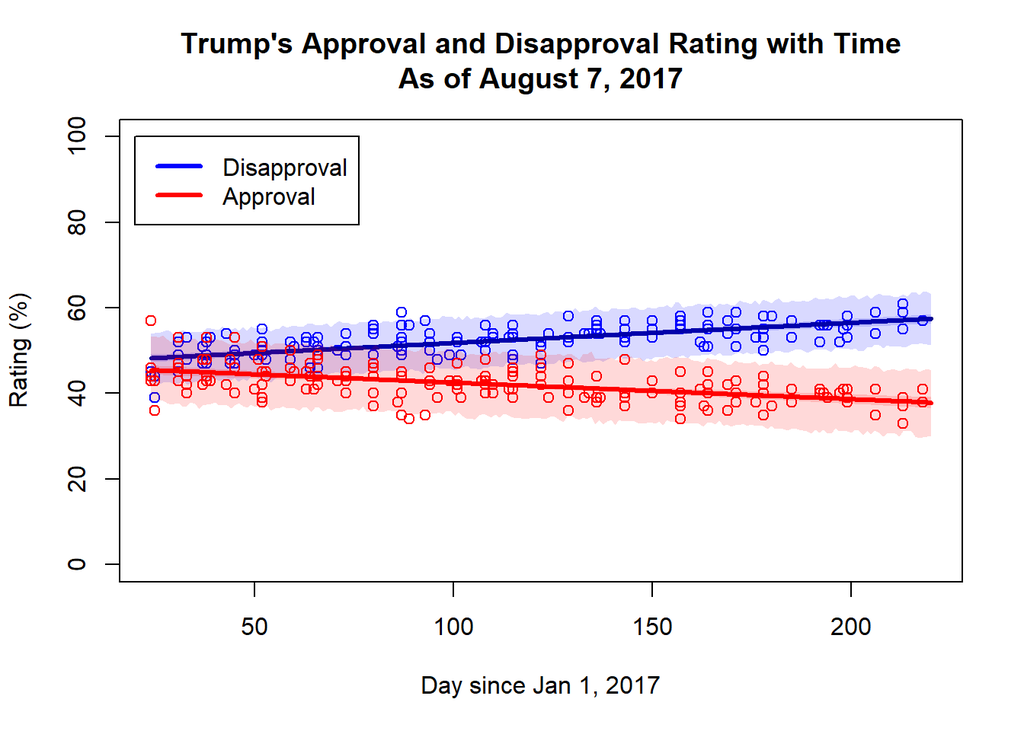

```r
# Get the 97% PI for those predictions
pred_HPDI <- apply(pred_app, 2, rethinking::HPDI, prob = 0.97)


# Plot raw points
plot(Approve ~ Day_of_year, data = tbls, pch = 21, col = "red",
     axes = FALSE, xlim = c(24, 220), ylim = c(0, 100),
     xlab = "", ylab = "",
     main = "Trump's Approval and Disapproval Rating with Time\nAs of August 7, 2017")


# Add the MAP line
lines(day_seq_all, mu_mean, lwd = 3, col = "red")


# Add the HPDI for the MAP line
rethinking::shade(mu_HPDI, day_seq_all, col = col.alpha("red", 0.15))


# Add the HPDI for the predictions
rethinking::shade(pred_HPDI, day_seq_all, col = col.alpha("red", 0.15))


# Add a legend
legend(x = 20, y = 100, c("Disapproval", "Approval"),
       col = c("blue", "red"), lwd = 3)
```

### Description

The model is fit to polling data from RealClearPolitics, and I got the idea to do this after seeing the following reddit thread: https://www.reddit.com/r/dataisbeautiful/comments/6ievy0/president_trumps_approval_disapproval_rating_oc/

As you can see the main result are two linear regressions, one for approval rating (red) and one for disapproval rating (blue). Each line is a *maximum a posteriori* (MAP) estimation based off the following priors:

#### Disapproval Rating

1. Disapproval Rating ~ Normal(mu, sigma)
2. mu = Alpha + Beta(Day of Year)
3. Alpha ~ Normal(48, 5)
4. Beta ~ Normal(0, 1)
5. sigma ~ Uniform(0, 5)

The mean of the Alpha (intercept) distribution is set to the approximate percent of the popular vote which Hillary Clinton received. Beta (the rate) is centered narrowly around 0 because the unit of change is days, which is almost guaranteed to yield little change. Sigma is restricted uniformly between 0 and 5 because I doubt the MAP estimate line will be off by more than 10. I use a basic linear regression for the sake of simplicity.

#### Approval Rating

1. Approval Rating ~ Normal(mu, sigma)
2. mu = Alpha + Beta(Day of Year)
3. Alpha ~ Normal(46, 5)
4. Beta ~ Normal(0, 1)
5. sigma ~ Uniform(0, 5)

All justifications here are largely the same with the exception that the mean of the Alpha distribution here is the approximate percent of the popular vote which Donald Trump received.

#### Shaded Intervals

The lines each have a narrowly shaded interval around them, showing the uncertainty in the lines themselves; these shaded regions contain the most plausible 97% of other possible MAP estimate lines. The larger shaded regions surrounding each line represent the area in which the models expect to find 97% of the actual poll ratings, whereas the lines show the mean/expected poll rating at each point in time.